# Lab Assignment: Chapter 17 - Probablity Distributions

Michael Beebe

```r
library(ggplot2)
library(reshape2)
library(stringr)
```

## 1. Probability Distribution

Using rnorm store 10 random numbers in a variable.

```r
rand10 <- rnorm(10)
rand10
```

```
##  [1] -0.27942734 -0.53511998 -0.13166143  0.66169530 -0.37187878 -1.17868987
##  [7]  0.06944716  0.40774435 -0.81232390 -0.12902548
```

Find the probabilities of your numbers from above.

```r
rand10Probs <- dnorm(rand10)
rand10Probs
```

```
##  [1] 0.3836677 0.3457238 0.3954994 0.3205045 0.3722888 0.1991706 0.3979814
##  [8] 0.3671201 0.2868277 0.3956354
```

Create 2 new variables - one that will store a large number of random variables, and the other that stores their density (probabilities)

```r
rand1000 <- rnorm(1000)
rand1000Probs <- dnorm(rand1000)
```

Plot the distribution using ggplot.

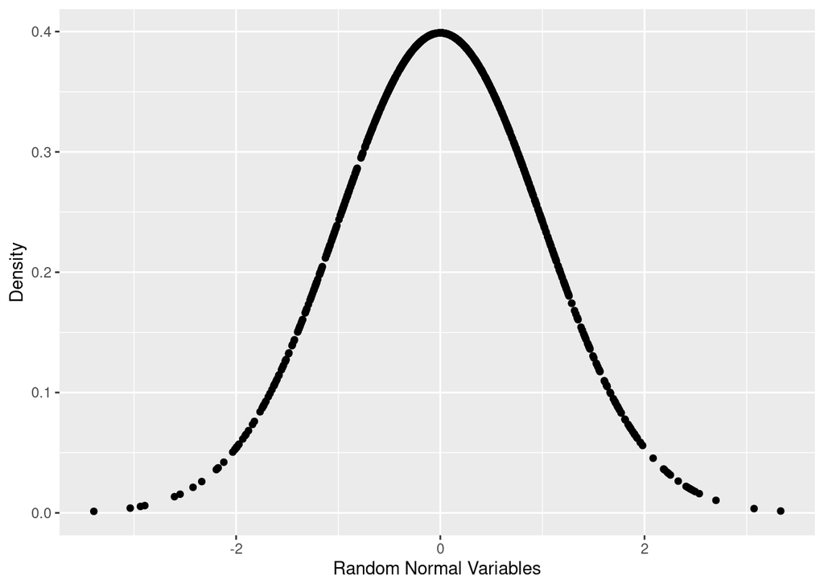

```r
ggplot(
  data.frame(x=rand1000, y=rand1000Probs)) +
  aes(x=x, y=y) +geom_point() +
  labs(x="Random Normal Variables", y="Density"
)
```

## 2. Binomial Distribution

Calculate the probability and cumulative probability using the Binomial Distribution using the following scenarios:

Probability of tossing a die 10 times and getting a “3” at least 2 times.

- Probability of a success is 1/6 = 0.17

```r
dbinom(x = 2, size = 10, prob = .17)
```

```
## [1] 0.2929106
```

Probability and getting at least a “B” (80%) on a quiz that has 10 true/false questions.

- Probability of getting a question right is 1/2 = 0.5.
- Use dbinom function to determine probability of getting a B by randomly guessing

```r
dbinom(x = 8, size = 10, prob = .5)
```

```
## [1] 0.04394531
```

- Use pbinom function to determine probability of answering 8 or less questions correctly by random guess.

```r
pbinom(q = 8, size = 10, prob = .5)
```

```
## [1] 0.9892578
```

Generate a graph based on a 10,000 random experiments, 10 trials, and 0.3 probability of success.

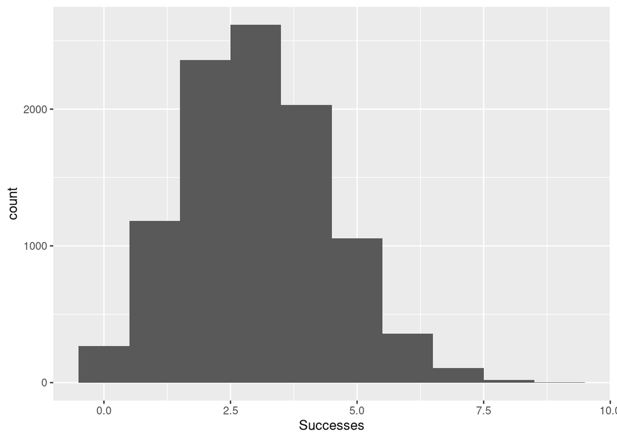

```r
binomData <- data.frame (Successes= rbinom (n=10000, size=10, prob=.3))
ggplot (data = binomData, aes (x=Successes)) + geom_histogram (binwidth=1)
```

## 3. Poisson Distribution

We are interested in calculating the probability that today at least 5 callers will receive a busy signal if they call Lakeland’s Help Desk.

- The average probability of a busy signal is 0.5%
- There are 1,200 calls to the Lakeland Help Desk
- Use the ppois function with lower=FALSE

```r
ppois(q = 1200, lambda = 0.005, lower.tail = FALSE)
```

```
## [1] 0
```

Generate the plot on page 238 and explain what it shows.

```r
pois1 <- rpois(n = 10000, lambda = 1)
pois2 <- rpois(n = 10000, lambda = 2)
pois5 <- rpois(n = 10000, lambda = 5)
pois10 <- rpois(n = 10000, lambda = 10)
pois20 <- rpois(n = 10000, lambda = 20)
pois <- data.frame(
  Lambda.1 = pois1,
  Lambda.2 = pois2,
  Lambda.5 = pois5,
  Lambda.10 = pois10,
  Lambda.20 = pois20
)

pois <- melt(data=pois, variable.name="Lambda", value.name="x")
```

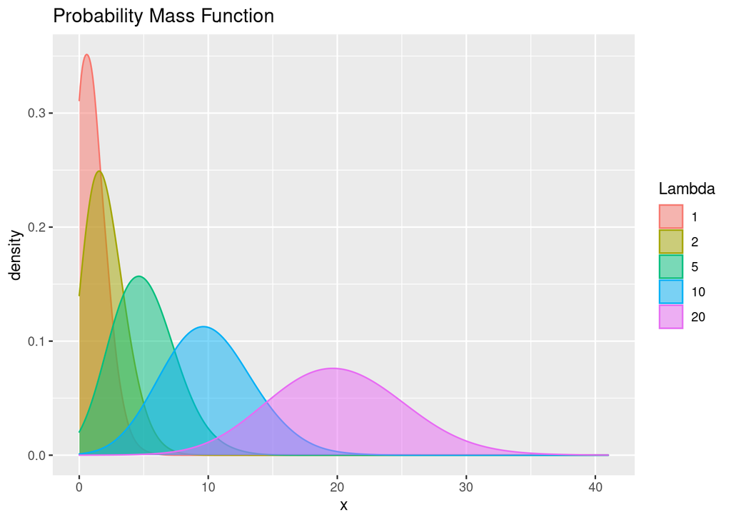

```r
pois$Lambda <- as.factor(
  as.numeric(
    str_extract(string=pois$Lambda, pattern="\\d+")
  )
)


ggplot (pois, aes (x=x)) +
geom_density ( aes (group=Lambda, color=Lambda, fill=Lambda), adjust=4, alpha=1/2) +
scale_color_discrete () + scale_fill_discrete () +
ggtitle ("Probability Mass Function")
```

This graph shows density plots for 10,000 draws from the Poisson distribution at varying levels of λ.